# R Notebook

```r
library(rpart)
library(rpart.plot)
library(tidyverse)
library(tidyverse)
```

```r
titanic_set <- read_csv("data/titanic_decision_tree_data.csv")
```

```r
shuffle_index <- sample(1:nrow(titanic_set))

# shuffle the data so class order isn't in order - need this for training/testing split later on
titanic_set <- titanic_set[shuffle_index, ]
```

```r
head(titanic_set)
```

| X1 | passenger_id | pclass | name | sex | age | sib_sp | parch | ticket | fare | cabin | embarked | survived |
| --- | --- | --- | --- | --- | --- | --- | --- | --- | --- | --- | --- | --- |
| 591 | 173 | 3 | Johnson, Miss. Eleanor Ileen | female | 1 | 1 | 1 | 347742 | 11.1333 | NA | S | 1 |
| 804 | 386 | 2 | Davies, Mr. Charles Henry | male | 18 | 0 | 0 | S.O.C. 14879 | 73.5000 | NA | S | 0 |
| 58 | 949 | 3 | Abelseth, Mr. Olaus Jorgensen | male | 25 | 0 | 0 | 348122 | 7.6500 | F G63 | S | NA |
| 874 | 456 | 3 | Jalsevac, Mr. Ivan | male | 29 | 0 | 0 | 349240 | 7.8958 | NA | C | 1 |
| 880 | 462 | 3 | Morley, Mr. William | male | 34 | 0 | 0 | 364506 | 8.0500 | NA | S | 0 |
| 1004 | 586 | 1 | Taussig, Miss. Ruth | female | 18 | 0 | 2 | 110413 | 79.6500 | E68 | S | 1 |

1.1

[output not shown]

[output cut: 702 more lines]

1.2 Question 2

Have a look at your data and create some plots to ensure you know what you’re working with before you begin. Write a summary of what you have found in your plots. Which variables do you think might be useful to predict whether or not people are going to die? Knowing this before you start is the best way to have a sanity check that your model is doing a good job.

```r
library(GGally)
```

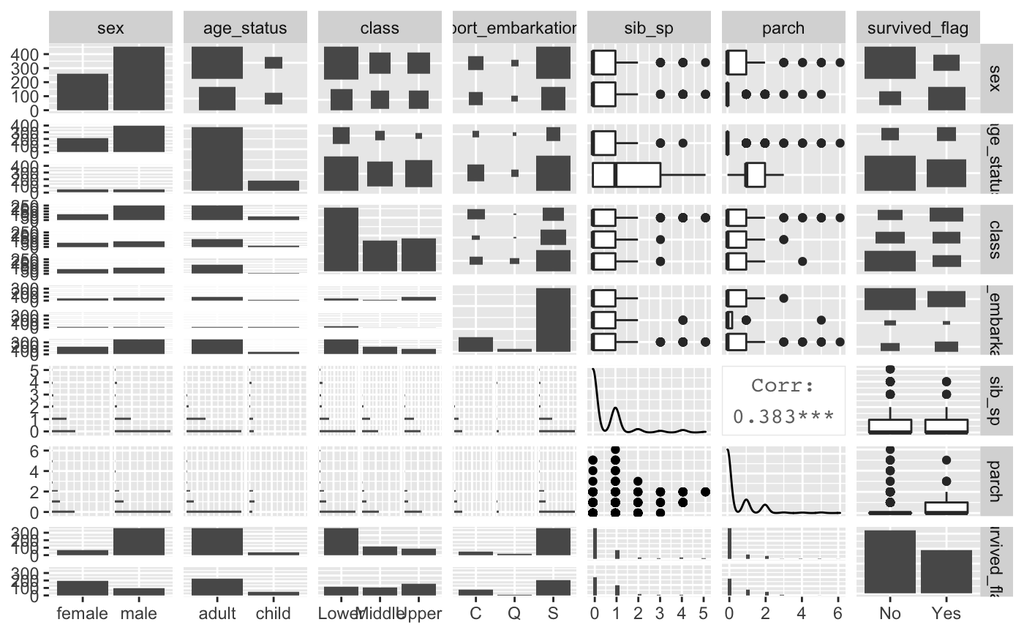

```r
ggpairs(titanic_clean)
```

1.3 Question 3

Now you can start to build your model. Create your testing and training set using an appropriate split. Check you have balanced sets. Write down why you chose the split you did and produce output tables to show whether or not it is balanced.

```r
n_data <- nrow(titanic_clean)

# created a text index
test_index <- sample(1:n_data, size = n_data*0.2)

#created test set

titanic_test <- slice(titanic_clean, test_index)

#created training data

titanic_train <- slice(titanic_clean, -test_index)
```

```r
library(janitor)
```

```r
titanic_test %>%
  tabyl(survived_flag)
```

```
 survived_flag  n   percent
            No 84 0.5915493
           Yes 58 0.4084507
```

[output not shown]

[output cut: 560 more lines]

These look pretty balanced datasets to work with, i chose the 20 percent as i thought it was a good starting point, given the size of the dataset

1.4 Question 4

Create your decision tree to try and predict survival probability using an appropriate method, and create a decision tree plot.

```r
titanic_fit <- rpart(survived_flag ~ .,
                     data = titanic_train,
                     method = "class")

titanic_fit
```

```
n= 570

node), split, n, loss, yval, (yprob)
      * denotes terminal node

 1) root 570 230 No (0.59649123 0.40350877)
   2) sex=male 357  74 No (0.79271709 0.20728291)
     4) class=Lower,Middle 279  40 No (0.85663082 0.14336918)
       8) age_status=adult 239  23 No (0.90376569 0.09623431) *
       9) age_status=child 40  17 No (0.57500000 0.42500000)
        18) sib_sp>=2.5 15   1 No (0.93333333 0.06666667) *
        19) sib_sp< 2.5 25   9 Yes (0.36000000 0.64000000)
          38) parch< 0.5 9   2 No (0.77777778 0.22222222) *
          39) parch>=0.5 16   2 Yes (0.12500000 0.87500000) *
     5) class=Upper 78  34 No (0.56410256 0.43589744)
      10) sib_sp< 0.5 52  19 No (0.63461538 0.36538462) *
      11) sib_sp>=0.5 26  11 Yes (0.42307692 0.57692308) *
   3) sex=female 213  57 Yes (0.26760563 0.73239437)
     6) class=Lower 87  39 No (0.55172414 0.44827586)
      12) sib_sp>=0.5 39  12 No (0.69230769 0.30769231) *
      13) sib_sp< 0.5 48  21 Yes (0.43750000 0.56250000) *
     7) class=Middle,Upper 126   9 Yes (0.07142857 0.92857143) *
```

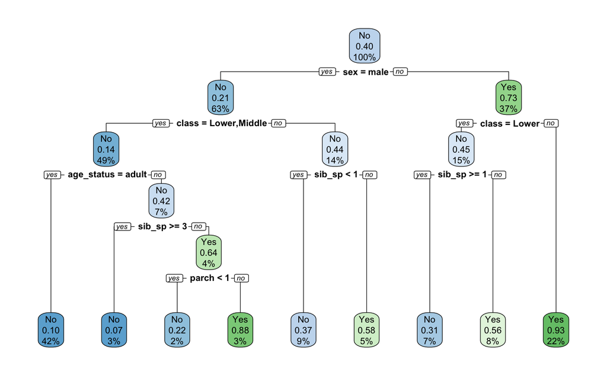

```r
rpart.plot(titanic_fit, yesno = 2)
```

This has decided that sex = male as the most important element, the important variable are sex = male, class = lower, middle, age_status = adult, slb_sp >= 3, parch < 1, slb_sp < 1, class = lower, slb_sp >= 1.

1.5 Question 6

Test and add your predicitons to your data. Create a confusion matrix. Write down in detial what this tells you for this specific dataset.

```r
library(modelr)
```

[output not shown]

[output cut: 132 more lines]

```r
# look at the variables

titanic_test_pred %>%
  select(sex, class, age_status, sib_sp, parch, pred)
```

| sex | class | age_status | sib_sp | parch | pred |
| --- | --- | --- | --- | --- | --- |
| male | Upper | adult | 0 | 0 | No |
| female | Upper | adult | 2 | 2 | Yes |
| male | Upper | adult | 1 | 1 | Yes |
| male | Lower | adult | 0 | 0 | No |
| male | Lower | adult | 1 | 0 | No |
| male | Lower | adult | 0 | 0 | No |
| male | Lower | adult | 0 | 0 | No |
| male | Middle | adult | 0 | 0 | No |
| female | Upper | adult | 1 | 1 | Yes |
| male | Lower | child | 4 | 1 | No |

[output cut: 132 more lines]

```r
rpart.predict(titanic_fit, newdata=titanic_test[1:3,], rules=TRUE)
```

| because | sex | is | male | & | class | is | Upper | & | sib_sp | < | 1 |
| --- | --- | --- | --- | --- | --- | --- | --- | --- | --- | --- | --- |
| because | sex | is | female | & | class | is | Middle or Upper |  |  |  |  |
| because | sex | is | male | & | class | is | Upper | & | sib_sp | >= | 1 |

[output not shown]

```r
library(yardstick)
```

```r
conf_mat <- titanic_test_pred %>%
              conf_mat(truth = survived_flag, estimate = pred)

conf_mat
```

```
          Truth
Prediction No Yes
       No  72  20
       Yes 12  38
```

This shows the the more accurate the tree the higher the diagonal will be. This should be pretty accurate

[output not shown]

```r
library(caret)
```

```r
confusionMatrix(titanic_test_pred$pred, titanic_test_pred$survived_flag)
```

```
Confusion Matrix and Statistics

          Reference
Prediction No Yes
       No  72  20
       Yes 12  38

               Accuracy : 0.7746
                 95% CI : (0.697, 0.8405)
    No Information Rate : 0.5915
    P-Value [Acc > NIR] : 3.249e-06

                  Kappa : 0.5235

 Mcnemar's Test P-Value : 0.2159

            Sensitivity : 0.8571
            Specificity : 0.6552
         Pos Pred Value : 0.7826
         Neg Pred Value : 0.7600
             Prevalence : 0.5915
         Detection Rate : 0.5070
   Detection Prevalence : 0.6479
      Balanced Accuracy : 0.7562

       'Positive' Class : No
```

CODECLAN_SOLUTION

```r
titanic_clean_1 <- titanic_set %>%
  filter(survived %in% c(0,1)) %>%
# Convert to factor level
    mutate(sex = as.factor(sex),
           age_status = as.factor(if_else(age <= 16, "child", "adult")),
         class = factor(pclass, levels = c(3,2,1), labels = c("Lower", "Middle", "Upper")),
           survived_flag = factor(survived, levels = c(0,1), labels = c("dies", "survived")),
           port_embarkation = as.factor(embarked)) %>%
  select(sex, age_status, class, port_embarkation, sib_sp, parch, survived_flag) %>%
  na.omit()
```

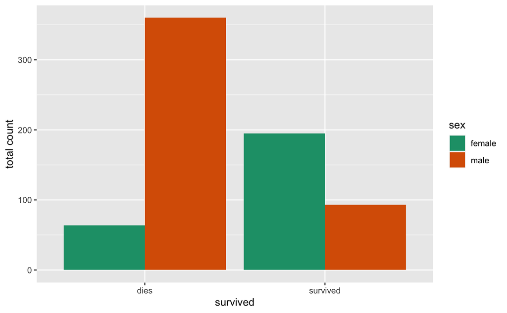

```r
titanic_clean_1 %>%
  select(survived_flag, sex) %>%
  group_by(survived_flag,sex) %>%
  summarise(total_count = n()) %>%
ggplot() +
  aes(x = survived_flag, y = total_count, fill = sex) +
  geom_bar(stat = "identity", position = position_dodge()) +
  scale_fill_brewer(palette="Dark2") +
  ylab("total count") + xlab("survived")
```

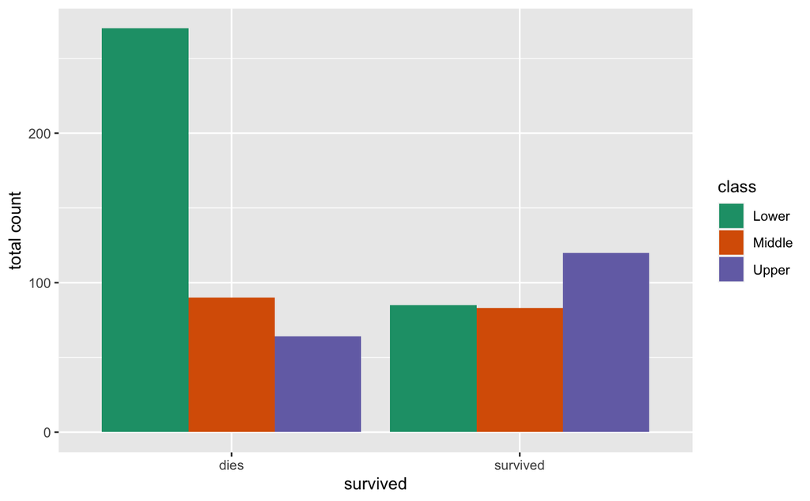

```r
titanic_clean_1 %>%
  select(survived_flag, class) %>%
  group_by(survived_flag,class) %>%
  summarise(total_count = n()) %>%
ggplot() +
  aes(x = survived_flag, y = total_count, fill = class) +
  geom_bar(stat = "identity", position = position_dodge()) +
  scale_fill_brewer(palette="Dark2") +
  ylab("total count") + xlab("survived")
```

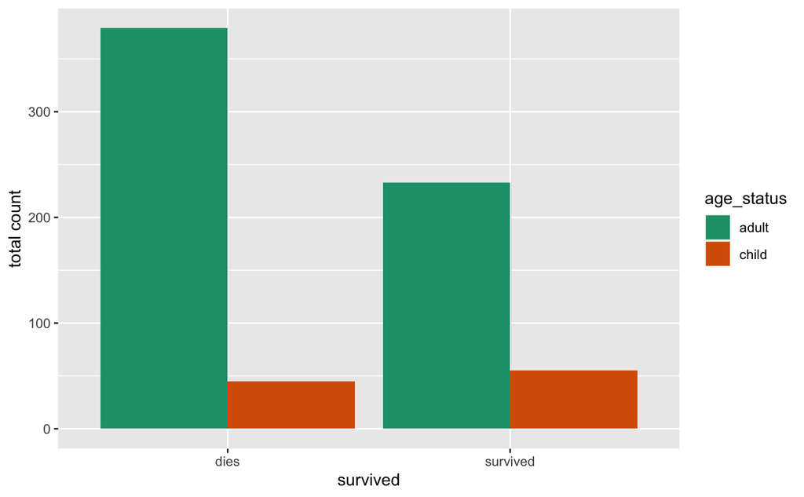

```r
titanic_clean_1 %>%
  select(survived_flag, age_status) %>%
  group_by(survived_flag,age_status) %>%
  summarise(total_count = n()) %>%
ggplot() +
  aes(x = survived_flag, y = total_count, fill = age_status) +
  geom_bar(stat = "identity", position = position_dodge()) +
  scale_fill_brewer(palette="Dark2") +
  ylab("total count") + xlab("survived")
```

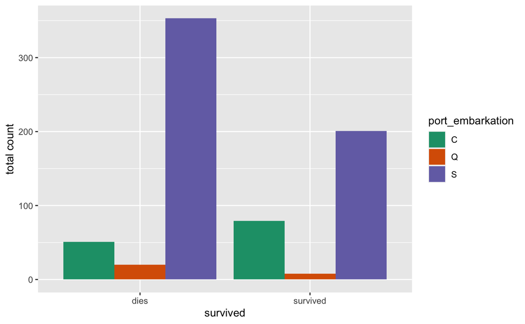

```r
titanic_clean_1 %>%
  select(survived_flag, port_embarkation) %>%
  group_by(survived_flag,port_embarkation) %>%
  summarise(total_count = n()) %>%
ggplot() +
  aes(x = survived_flag, y = total_count, fill = port_embarkation) +
  geom_bar(stat = "identity", position = position_dodge()) +
  scale_fill_brewer(palette="Dark2") +
  ylab("total count") + xlab("survived")
```

```r
# set the random seed number: ONLY INSTRUCTORS - students SHOULD NOT do this in their homework
set.seed(3)

n_data_1 <- nrow(titanic_clean_1)

# create a test sample index
test_index_1 <- sample(1:n_data, size = n_data*0.2)

# create test set
titanic_test_1  <- slice(titanic_clean_1, test_index)

# create training set
titanic_train_1 <- slice(titanic_clean_1, -test_index)

# check balanced sets
titanic_test_1 %>%
 janitor::tabyl(survived_flag)
```

```
 survived_flag  n   percent
          dies 84 0.5915493
      survived 58 0.4084507
```

```r
titanic_train_1 %>%
  janitor::tabyl(survived_flag)
```

```
 survived_flag   n   percent
          dies 340 0.5964912
      survived 230 0.4035088
```

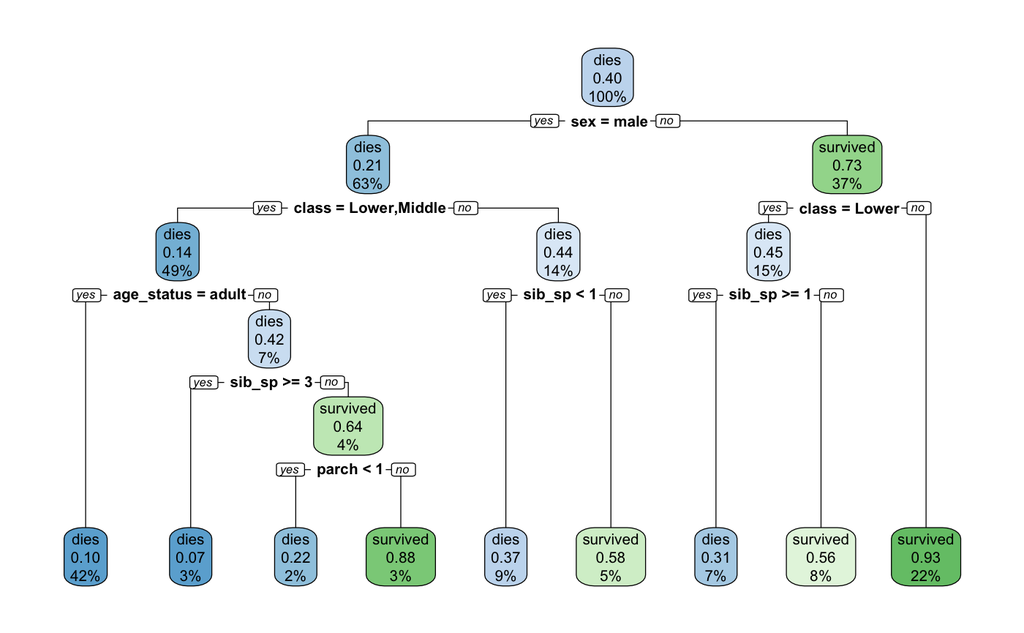

```r
titanic_fit_1 <- rpart(survived_flag ~ .,
                     data = titanic_train_1,
                     method = 'class')

rpart.plot(titanic_fit_1, yesno = 2)
```

```r
library(modelr)
library(yardstick)
```

```r
# add the predictions
titanic_test_pred_1 <- titanic_test_1 %>%
                 add_predictions(titanic_fit_1, type = 'class')


conf_mat <- titanic_test_pred_1 %>%
              conf_mat(truth = survived_flag, estimate = pred)

conf_mat
```

[output not shown]

EXTENSION

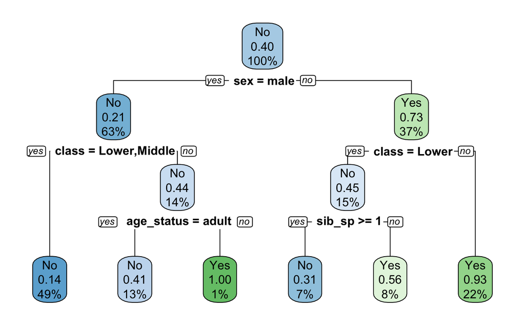

```r
control <- rpart.control(minsplit = 4,
    minbucket = round(5 / 3),
    maxdepth = 3,
    cp = 0)

tune_fit <- rpart(survived_flag ~., data = titanic_train, method = 'class', control = control)

rpart.plot(tune_fit, yesno = 2)
```